LAL BABU

PGDDS Batch9

Assignment-1

# *Automobile Dataset*

[figure not shown]

```python
import matplotlib.pyplot as plt
import pandas as pd
import seaborn as sns
import tensorflow as tf
from tensorflow import keras
from tensorflow.keras import layers

print(tf.__version__)
```

```
2.4.1
```

# There is an automobile dataset to predict the fuel efficiency. We need to implement the Linear Regression using Feed forward neural network (MLP architecture)

the target variable name is ‘MPG’ in the dataset.

we will categorise dataset in dependent and independent variables and further will use as train and test data

**Import the required libraries**

Here we will be making use of the Keras library for creating our model and training it. We also use Matplotlib and Seaborn for visualizing our dataset to gain a better understanding of the data we are going to be handling

```python
import keras

from keras.models import Sequential

from keras.layers import Dense

# from keras.preprocessing.image import ImageDataGenerator

# from keras.optimizers import Adam

from sklearn.metrics import classification_report, confusion_matrix

# import tensorflow as tf

import numpy as np
```

```python
import matplotlib.pyplot as plt
import pandas as pd
import seaborn as sns
import tensorflow as tf
from tensorflow import keras
from tensorflow.keras import layers
```

**Loading the data**

define the path to our data

```python
dataset_path = keras.utils.get_file("auto-mpg.data",
"http://archive.ics.uci.edu/ml/machine-learning-databases/auto-mpg/auto-mpg.data")


column_names = ['MPG','Cylinders','Displacement','Horsepower','Weight',
'Acceleration', 'Model Year', 'Origin']

dataset = pd.read_csv(dataset_path, names=column_names,
na_values = "?", comment='\t',
sep=" ", skipinitialspace=True)
```

```python
dataset.shape    #it defines the total columns and rows in our dataframe
```

```
(398, 8)
```

```python
dataset.head()    #head() methods gives the first five record by default
```

|  | MPG | Cylinders | Displacement | Horsepower | Weight | Acceleration | Model Year | Origin |
| --- | --- | --- | --- | --- | --- | --- | --- | --- |
| 0 | 18.0 | 8 | 307.0 | 130.0 | 3504.0 | 12.0 | 70 | 1 |
| 1 | 15.0 | 8 | 350.0 | 165.0 | 3693.0 | 11.5 | 70 | 1 |
| 2 | 18.0 | 8 | 318.0 | 150.0 | 3436.0 | 11.0 | 70 | 1 |
| 3 | 16.0 | 8 | 304.0 | 150.0 | 3433.0 | 12.0 | 70 | 1 |
| 4 | 17.0 | 8 | 302.0 | 140.0 | 3449.0 | 10.5 | 70 | 1 |

```python
dataset.info()  #it gives information like features and datatype of each features, null values present in dataset
```

```
<class 'pandas.core.frame.DataFrame'>
RangeIndex: 398 entries, 0 to 397
Data columns (total 8 columns):
 #   Column        Non-Null Count  Dtype
---  ------        --------------  -----
 0   MPG           398 non-null    float64
 1   Cylinders     398 non-null    int64
 2   Displacement  398 non-null    float64
 3   Horsepower    392 non-null    float64
 4   Weight        398 non-null    float64
 5   Acceleration  398 non-null    float64
 6   Model Year    398 non-null    int64
 7   Origin        398 non-null    int64
dtypes: float64(5), int64(3)
memory usage: 25.0 KB
```

```python
dataset.describe()  #describe() methods gives details of descriptive statistics of numerical features
```

|  | MPG | Cylinders | Displacement | Horsepower | Weight | Acceleration | Model Year | Origin |
| --- | --- | --- | --- | --- | --- | --- | --- | --- |
| count | 398.000000 | 398.000000 | 398.000000 | 392.000000 | 398.000000 | 398.000000 | 398.000000 | 398.000000 |
| mean | 23.514573 | 5.454774 | 193.425879 | 104.469388 | 2970.424623 | 15.568090 | 76.010050 | 1.572864 |
| std | 7.815984 | 1.701004 | 104.269838 | 38.491160 | 846.841774 | 2.757689 | 3.697627 | 0.802055 |
| min | 9.000000 | 3.000000 | 68.000000 | 46.000000 | 1613.000000 | 8.000000 | 70.000000 | 1.000000 |
| 25% | 17.500000 | 4.000000 | 104.250000 | 75.000000 | 2223.750000 | 13.825000 | 73.000000 | 1.000000 |
| 50% | 23.000000 | 4.000000 | 148.500000 | 93.500000 | 2803.500000 | 15.500000 | 76.000000 | 1.000000 |
| 75% | 29.000000 | 8.000000 | 262.000000 | 126.000000 | 3608.000000 | 17.175000 | 79.000000 | 2.000000 |
| max | 46.600000 | 8.000000 | 455.000000 | 230.000000 | 5140.000000 | 24.800000 | 82.000000 | 3.000000 |

```python
dataset.isnull().sum()   # it helps in finding null values present in each columns. in this data except "Horsepower", none has none value present
```

```
MPG             0
Cylinders       0
Displacement    0
Horsepower      6
Weight          0
Acceleration    0
Model Year      0
Origin          0
dtype: int64
```

```python
dataset['Horsepower']=dataset.Horsepower.fillna((dataset['Horsepower'].mean())) #fillna() function is used to remove or replace null values
```

```python
dataset.isnull().sum()
```

```
MPG             0
Cylinders       0
Displacement    0
Horsepower      0
Weight          0
Acceleration    0
Model Year      0
Origin          0
dtype: int64
```

Plot pairwise relationships in a dataset.

By default, this function will create a grid of Axes such that each numeric variable in data will by shared across the y-axes across a single row and the x-axes across a single column. The diagonal plots are treated differently: a univariate distribution plot is drawn to show the marginal distribution of the data in each column.

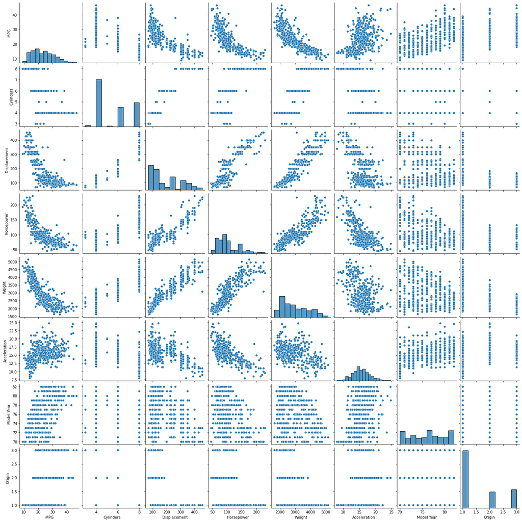

```python
sns.pairplot(dataset[['MPG','Cylinders','Displacement','Horsepower','Weight',
'Acceleration', 'Model Year', 'Origin']])
```

```python
dataset_independent = dataset[['Cylinders','Displacement','Horsepower','Weight',
'Acceleration', 'Model Year', 'Origin']]
```

## COLINIARITY CHECK

```python
  '''correlation is used to test the collinearity relationship between variables,
 it is a measure to estimate how things are related. if two variable has high colinearity then we can
skip one variable out of two and it will not impact or impact may be insignificant in our prediction model'''


dataset_independent.corr()
```

|  | Cylinders | Displacement | Horsepower | Weight | Acceleration | Model Year | Origin |
| --- | --- | --- | --- | --- | --- | --- | --- |
| Cylinders | 1.000000 | 0.950721 | 0.838939 | 0.896017 | -0.505419 | -0.348746 | -0.562543 |
| Displacement | 0.950721 | 1.000000 | 0.893646 | 0.932824 | -0.543684 | -0.370164 | -0.609409 |
| Horsepower | 0.838939 | 0.893646 | 1.000000 | 0.860574 | -0.684259 | -0.411651 | -0.453669 |
| Weight | 0.896017 | 0.932824 | 0.860574 | 1.000000 | -0.417457 | -0.306564 | -0.581024 |
| Acceleration | -0.505419 | -0.543684 | -0.684259 | -0.417457 | 1.000000 | 0.288137 | 0.205873 |
| Model Year | -0.348746 | -0.370164 | -0.411651 | -0.306564 | 0.288137 | 1.000000 | 0.180662 |
| Origin | -0.562543 | -0.609409 | -0.453669 | -0.581024 | 0.205873 | 0.180662 | 1.000000 |

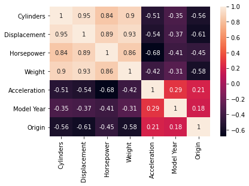

```python
sns.heatmap(dataset_independent.corr(),annot = True)
```

```python
# divide the data into train and test with 80 percent and 20 per respectively

train_data = dataset.sample(frac =0.8, random_state = 0)
test_data = dataset.drop(train_data.index)
```

```python
train_data.describe()
```

|  | MPG | Cylinders | Displacement | Horsepower | Weight | Acceleration | Model Year | Origin |
| --- | --- | --- | --- | --- | --- | --- | --- | --- |
| count | 318.000000 | 318.000000 | 318.000000 | 318.000000 | 318.000000 | 318.000000 | 318.000000 | 318.000000 |
| mean | 23.590566 | 5.427673 | 193.061321 | 104.073418 | 2963.823899 | 15.595912 | 75.946541 | 1.553459 |
| std | 7.913617 | 1.682941 | 103.812742 | 38.368477 | 844.749805 | 2.796282 | 3.705266 | 0.799430 |
| min | 10.000000 | 3.000000 | 70.000000 | 46.000000 | 1613.000000 | 8.000000 | 70.000000 | 1.000000 |
| 25% | 17.125000 | 4.000000 | 100.250000 | 75.250000 | 2219.250000 | 13.900000 | 73.000000 | 1.000000 |
| 50% | 22.750000 | 4.000000 | 151.000000 | 92.000000 | 2792.500000 | 15.500000 | 76.000000 | 1.000000 |
| 75% | 29.000000 | 6.000000 | 259.500000 | 120.000000 | 3571.250000 | 17.300000 | 79.000000 | 2.000000 |
| max | 46.600000 | 8.000000 | 455.000000 | 230.000000 | 5140.000000 | 24.800000 | 82.000000 | 3.000000 |

```python
test_data.describe()
```

|  | MPG | Cylinders | Displacement | Horsepower | Weight | Acceleration | Model Year | Origin |
| --- | --- | --- | --- | --- | --- | --- | --- | --- |
| count | 80.000000 | 80.000000 | 80.000000 | 80.000000 | 80.000000 | 80.000000 | 80.000000 | 80.000000 |
| mean | 23.212500 | 5.562500 | 194.875000 | 106.043367 | 2996.662500 | 15.457500 | 76.262500 | 1.650000 |
| std | 7.455528 | 1.777808 | 106.718413 | 37.715993 | 859.968618 | 2.612568 | 3.679377 | 0.812871 |
| min | 9.000000 | 3.000000 | 68.000000 | 48.000000 | 1755.000000 | 8.500000 | 70.000000 | 1.000000 |
| 25% | 17.500000 | 4.000000 | 107.000000 | 78.250000 | 2240.750000 | 13.650000 | 73.000000 | 1.000000 |
| 50% | 23.450000 | 4.000000 | 143.000000 | 96.000000 | 2885.500000 | 15.200000 | 76.000000 | 1.000000 |
| 75% | 29.000000 | 8.000000 | 302.500000 | 133.500000 | 3740.000000 | 16.925000 | 80.000000 | 2.000000 |
| max | 43.100000 | 8.000000 | 400.000000 | 215.000000 | 4955.000000 | 22.200000 | 82.000000 | 3.000000 |

```python
train_stats = train_data.describe()
train_stats.pop('MPG')
train_stats = train_stats.transpose()
```

```python
train_stats
```

|  | count | mean | std | min | 25% | 50% | 75% | max |
| --- | --- | --- | --- | --- | --- | --- | --- | --- |
| Cylinders | 318.0 | 5.427673 | 1.682941 | 3.0 | 4.00 | 4.0 | 6.00 | 8.0 |
| Displacement | 318.0 | 193.061321 | 103.812742 | 70.0 | 100.25 | 151.0 | 259.50 | 455.0 |
| Horsepower | 318.0 | 104.073418 | 38.368477 | 46.0 | 75.25 | 92.0 | 120.00 | 230.0 |
| Weight | 318.0 | 2963.823899 | 844.749805 | 1613.0 | 2219.25 | 2792.5 | 3571.25 | 5140.0 |
| Acceleration | 318.0 | 15.595912 | 2.796282 | 8.0 | 13.90 | 15.5 | 17.30 | 24.8 |
| Model Year | 318.0 | 75.946541 | 3.705266 | 70.0 | 73.00 | 76.0 | 79.00 | 82.0 |
| Origin | 318.0 | 1.553459 | 0.799430 | 1.0 | 1.00 | 1.0 | 2.00 | 3.0 |

```python
# dividing target variable into train and train dataset

train_labels = train_data.pop('MPG')
test_labels = test_data.pop('MPG')
```

# Normalization

when multiple attributes are there but attributes have values on different scales, this may lead to poor data models while performing data mining operations. So they are normalized to bring all the attributes on the same scale.

```python
def norm(x):
  return (x - train_stats['mean']) / train_stats['std']

normed_train_data = norm(train_data)
normed_test_data = norm(test_data)
```

# Model building using ##keras library

"relu" is widely used activation function.ReLU stands for Rectified Linear Unit. The main advantage of using the ReLU function over other activation functions is that it does not activate all the neurons at the same time. ... Due to this reason, during the backpropogation process, the weights and biases for some neurons are not updated

We are defining two hiden layer with 64 perceptron at each level

input_shape object is used to pass number of input features into model

```python
# build the model

def build_model():
  model = keras.Sequential([
                            layers.Dense(64, activation = 'relu',input_shape = [len(train_data.keys())]),
                            layers.Dense(64, activation='relu'),
                            layers.Dense(1)
                            ])
  optimizer = tf.keras.optimizers.RMSprop(learning_rate=0.001)  #default learning rate is 0.001
  model.compile(loss = 'mse',
                optimizer = optimizer,
                metrics = ['mae','mse','mape'])
  return model
```

```python
model = build_model()
```

```python
model.summary()
```

```
Model: "sequential_2"
_________________________________________________________________
Layer (type)                 Output Shape              Param #
=================================================================
dense_6 (Dense)              (None, 64)                512
_________________________________________________________________
dense_7 (Dense)              (None, 64)                4160
_________________________________________________________________
dense_8 (Dense)              (None, 1)                 65
=================================================================
Total params: 4,737
Trainable params: 4,737
Non-trainable params: 0
_________________________________________________________________
```

## In summary, we can see that model has three layer, out of which two are hidden and Dense layer says that each parameter is connected. we have used 64 perceptron at layer first and second and Param shows the number of parameter or weight at each layer

```python
model.fit(test_data,test_labels, epochs =600, verbose =1)
```

```
<tensorflow.python.keras.callbacks.History at 0x7f04ada80490>
```

```python
# display training progress by printing a single dot for each completed epochs
class printDot(keras.callbacks.Callback):
  def on_epoch_end(self, epoch, logs):
    if epoch % 100 == 0:
      print('')
      print('.',end = '')

EPOCHS = 600

history = model.fit(
    normed_train_data, train_labels,
   epochs = EPOCHS, validation_split = 0.2, verbose=1, callbacks = [printDot()])
```

```
.Epoch 2/600

.Epoch 102/600

.Epoch 202/600

.Epoch 302/600

.Epoch 402/600

.Epoch 502/600
```

```python
hist = pd.DataFrame(history.history)
hist['epoch'] = history.epoch
hist.tail()
```

[output not shown]

[figure not shown]

[figure not shown]

```python
def plot_history(history):
  hist = pd.DataFrame(history.history)
  hist['epoch'] = history.epoch

  plt.figure()
  plt.xlabel('Epoch')
  plt.ylabel('Mean Abs Error [MEDV]')
  plt.plot(hist['epoch'],  hist['mae'], label = 'Train Error')
  plt.plot(hist['epoch'], hist['val_mae'], label = 'Validation Error')
  plt.ylim([0,5])
  plt.legend()


  plt.figure()
  plt.xlabel('Epoch')
  plt.ylabel('Mean Square Error [$MEDV^2$]')
  plt.plot(hist['epoch'],  hist['mse'], label = 'Train Error')
  plt.plot(hist['epoch'], hist['val_mse'], label = 'Val Error')
  plt.ylim([0,20])
  plt.legend()
  plt.show()

plot_history(history)
```

From graphical representation we can assume that the max epoch need to be restricted near about 200. For that we will use earlystopping method. in early stopping patience parameter is to check the loss at each epoch and if loss is not improving significantly then iterration will be stopped after given patience number

```python
model = build_model()


early_stop = keras.callbacks.EarlyStopping(monitor = 'val_loss', patience= 10)

history = model.fit(normed_train_data, train_labels, epochs = EPOCHS,
                    validation_split = 0.2, verbose =1, callbacks = [early_stop, printDot()])
```

```
.Epoch 2/600

.Epoch 102/600
```

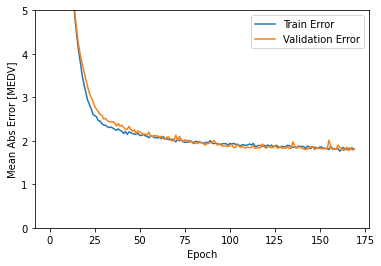

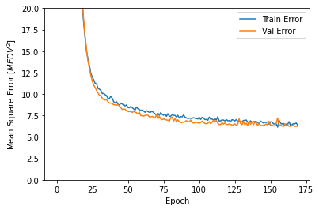

```python
plot_history(history)
```

```python
mse = model.evaluate(normed_test_data, test_labels, verbose =0)
print("Testing set mean abs Error: ", mse)
```

```
Testing set mean abs Error:  [7.518109321594238, 1.9162582159042358, 7.518109321594238, 8.456174850463867]
```

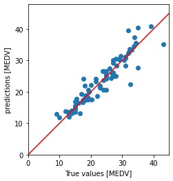

```python
# make predictions

test_predictions = model.predict(normed_test_data).flatten()
train_predictions = model.predict(normed_train_data).flatten()


plt.scatter(test_labels, test_predictions)
plt.xlabel('True values [MEDV]')
plt.ylabel('predictions [MEDV]')
plt.axis('equal')
plt.axis('square')
plt.xlim([0,plt.xlim()[1]])
plt.ylim([0,plt.ylim()[1]])
plt.plot([-100,100], [-100,100], color = 'red')
plt.show()
```

## most of the data points are along the best fit line